# General Social Survey

Year 2019

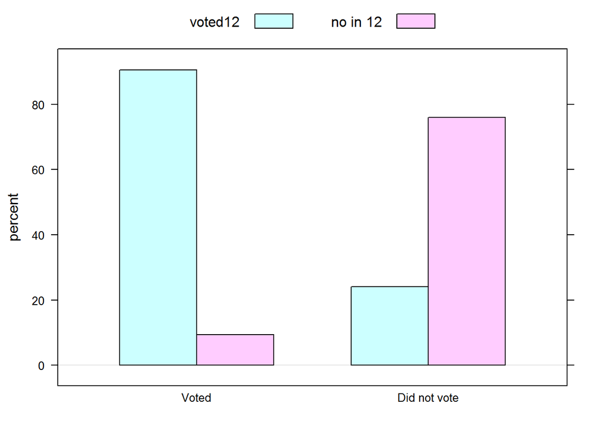

```r
barchartGC(~VOTE16+VOTE12, data=mydata4, type = "percent")
```

```r
chisqtestGC(~VOTE16+VOTE12, data=mydata4)
```

```
## Pearson's Chi-squared test with Yates' continuity correction
##
## Observed Counts:
##               VOTE12
## VOTE16         voted12 no in 12
##   Voted            116       12
##   Did not vote      12       38
##
## Counts Expected by Null:
##               VOTE12
## VOTE16         voted12 no in 12
##   Voted          92.04    35.96
##   Did not vote   35.96    14.04
##
## Contributions to the chi-square statistic:
##               VOTE12
## VOTE16         voted12 no in 12
##   Voted           6.23    15.96
##   Did not vote   15.96    40.86
##
##
## Chi-Square Statistic = 75.7483
## Degrees of Freedom of the table = 1
## P-Value = 0
```

```r
votetab=xtabs(~VOTE16+VOTE12, data=mydata4)
fisher.test(votetab)
```

```
##
##  Fisher's Exact Test for Count Data
##
## data:  votetab
## p-value < 2.2e-16
## alternative hypothesis: true odds ratio is not equal to 1
## 95 percent confidence interval:
##  11.74522 81.42075
## sample estimates:
## odds ratio
##   29.60721
```

# 1 Introduction Question 1

This data is from the 2018 General Social Survey. The first blocks of R-code has selected down a subset of the data to just 15 variables. It has further removed unwanted factor levels in much of the data. Examine that code to see what it is doing. First explain what you make out of comparing how people voted in 2012 with 2016.

## 1.1 Methods

## 1.2 Results

### 1.2.1 Descriptive Results

#### 1.2.1.1 Graphical Descriptive Results

#### 1.2.1.2 Numerical Descriptive Results

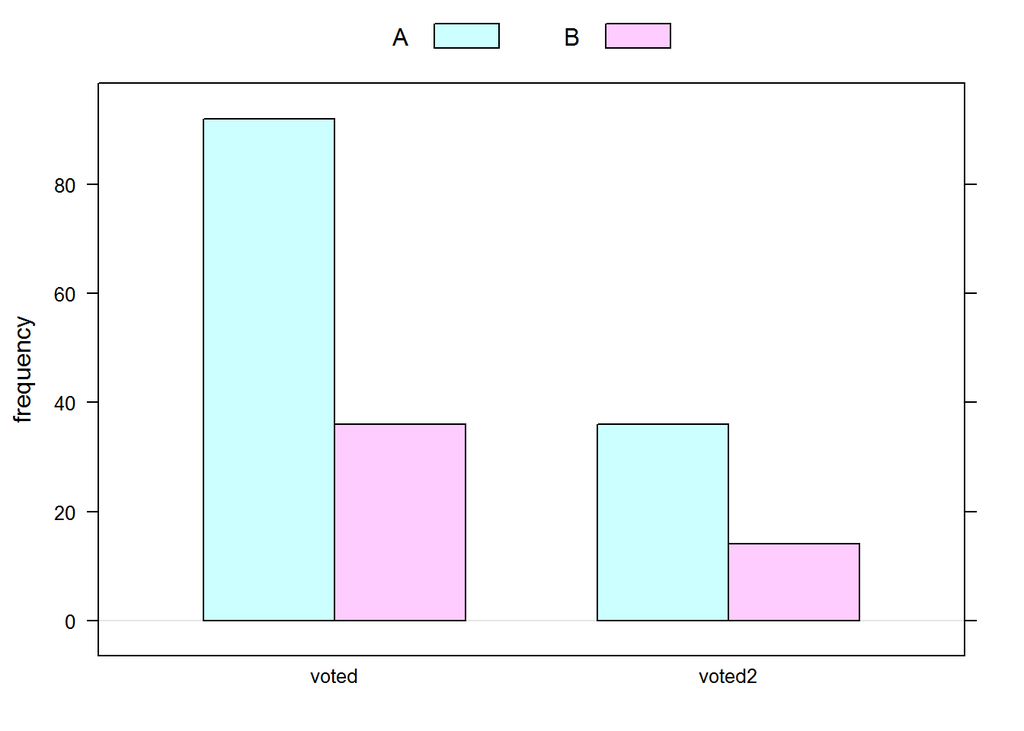

```r
voted=c(92.04 , 35.96)
voted2=c(35.96 , 14.04)
tabl =rbind(voted,voted2)
barchartGC(tabl)
```

### 1.2.2 Inferential Results

# 2 Introduction Question 2

Now answer Is belief in the bigbang theory (BIGBANG) independent of belief in the afterlife (POSTLIFE)

## 2.1 Methods

### 2.1.1 Descriptive Results

#### 2.1.1.1 Graphical Descriptive Results

#### 2.1.1.2 Numerical Descriptive Results

### 2.1.2 Inferential Results

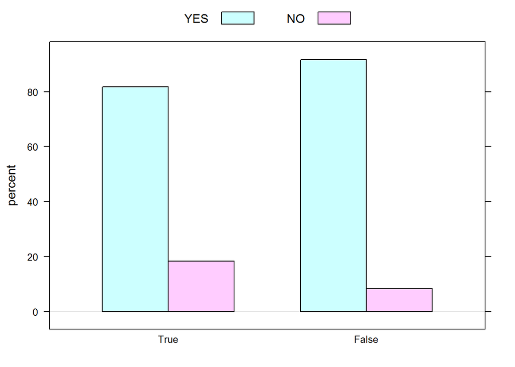

```r
barchartGC(~BIGBANG+POSTLIFE, data=mydata4, type = "percent")
```

```r
chisqtestGC(~BIGBANG+POSTLIFE, data=mydata4)
```

```
## Pearson's Chi-squared test with Yates' continuity correction
##
## Observed Counts:
##        POSTLIFE
## BIGBANG YES NO
##   True   67 15
##   False  88  8
##
## Counts Expected by Null:
##        POSTLIFE
## BIGBANG  YES   NO
##   True  71.4 10.6
##   False 83.6 12.4
##
## Contributions to the chi-square statistic:
##        POSTLIFE
## BIGBANG  YES   NO
##   True  0.27 1.83
##   False 0.23 1.56
##
##
## Chi-Square Statistic = 3.0637
## Degrees of Freedom of the table = 1
## P-Value = 0.0801
```

```r
votetab=xtabs(~BIGBANG+POSTLIFE, data=mydata4)
fisher.test(votetab)
```

```
##
##  Fisher's Exact Test for Count Data
##
## data:  votetab
## p-value = 0.07143
## alternative hypothesis: true odds ratio is not equal to 1
## 95 percent confidence interval:
##  0.1410591 1.0968350
## sample estimates:
## odds ratio
##  0.4081275
```

$H_0$ : if someone belives in the big bang they belive in the after life.  
$H_a$ : if someone belives in the big bang they do not belive in the afterlife.

Viewing the graph and p-value one can conclude that they could not be diffrent. the P value turned out to be 0.08 and because that number is bigger than 0.05 we cannot state that they are diffrent. and because the 95 % confidence intreval numbers are 0.1410591 & 1.0968350 the number 1 is between them. therefore, we fail to reject the null hypothosis.

### 2.1.3 Introduction Question 3

This time compare the opinion on death penalty (CAPPUN) with opinion on courts (COURTS).

## 2.2 Methods

we will see if there is a diffrence between the belief in capitol punishment and the opinion of courts by using varible analisys that include using a bar chart, a chi squared test and a fisher exact test.

## 2.3 Results

### 2.3.1 Descriptive Results

#### 2.3.1.1 Graphical Descriptive Results

#### 2.3.1.2 Numerical Descriptive Results

### 2.3.2 Inferential Results

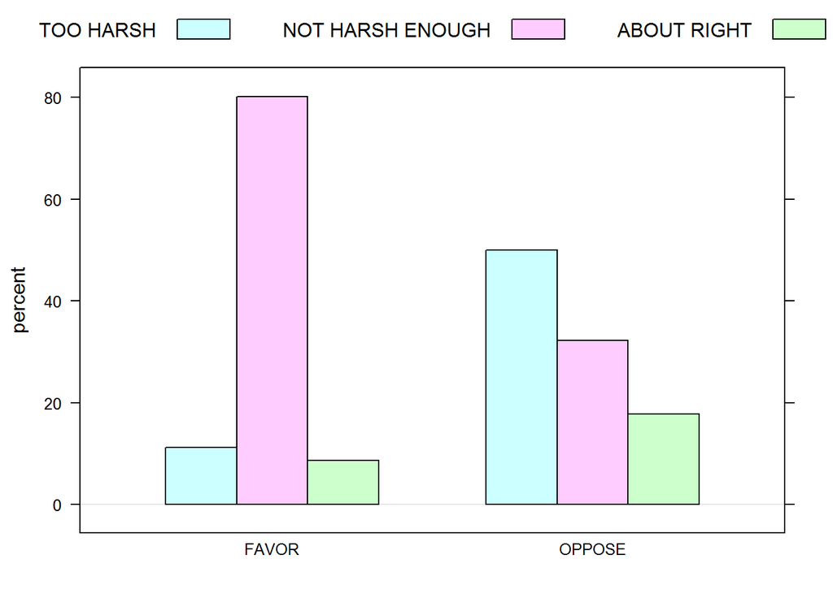

```r
barchartGC(~CAPPUN+COURTS, data=mydata4, type = "percent")
```

```r
chisqtestGC(~CAPPUN+COURTS, data=mydata4)
```

```
## Pearson's Chi-squared test
##
## Observed Counts:
##         COURTS
## CAPPUN   TOO HARSH NOT HARSH ENOUGH ABOUT RIGHT
##   FAVOR         13               93          10
##   OPPOSE        31               20          11
##
## Counts Expected by Null:
##         COURTS
## CAPPUN   TOO HARSH NOT HARSH ENOUGH ABOUT RIGHT
##   FAVOR      28.67            73.64       13.69
##   OPPOSE     15.33            39.36        7.31
##
## Contributions to the chi-square statistic:
##         COURTS
## CAPPUN   TOO HARSH NOT HARSH ENOUGH ABOUT RIGHT
##   FAVOR       8.57             5.09        0.99
##   OPPOSE     16.03             9.52        1.86
##
##
## Chi-Square Statistic = 42.0594
## Degrees of Freedom of the table = 2
## P-Value = 0
```

```r
votetab=xtabs(~CAPPUN+COURTS, data=mydata4)
fisher.test(votetab)
```

```
##
##  Fisher's Exact Test for Count Data
##
## data:  votetab
## p-value = 4.35e-10
## alternative hypothesis: two.sided
```

$H_0$ : peoples belifes of capitol punishment correlate to whether or not they think the courts are harsh enough.  
$H_a$ : peoples belifes of capitol punishment dont correlate to whether or not they think the courts are harsh enough.

# 3 Discussion and Conclusion